# Coding Club Time Series Tutorial

James Robinson

24/03/2021

Taken from: https://ourcodingclub.github.io/tutorials/time/

## Getting started

#### Set working drive

```r
setwd("C:/Users/s1679680/OneDrive - University of Edinburgh/OneDrive Documents/R/Github/CC-time-series")
```

#### Load packages

```r
library(ggplot2)
library(forecast)
library(dplyr)
library(colortools)
```

#### Load data

```r
monthly_milk <- read.csv("monthly_milk.csv")  # Milk production per cow per month
daily_milk <- read.csv("daily_milk.csv")  # Milk production per cow per milking
```

## 1. Formatting time series data

The most common issue when using time series data in `R` is getting it into a format that is easily readable by `R` and any extra packages you are using. A common format for time series data puts the largest chunk of time first (e.g. year) and gets progressively smaller, like this:

`2017-02-25 18:30:45`

This can be generalised to `YYYY-MM-DD HH:MM:SS.` If you can record your data in this format to begin with, analysis will be much easier. If time isn’t important for your measurements, you can drop the HH:MM:SS bit from your records.

The data in `monthly_milk` shows the monthly milk production by a herd of cattle between 1962 and 1975. First, we should check the form of the data set:

```r
head(monthly_milk)
```

```
##        month milk_prod_per_cow_kg
## 1 1962-01-01               265.05
## 2 1962-02-01               252.45
## 3 1962-03-01               288.00
## 4 1962-04-01               295.20
## 5 1962-05-01               327.15
## 6 1962-06-01               313.65
```

```r
class(monthly_milk)
```

```
## [1] "data.frame"
```

```r
class(monthly_milk$month)
```

```
## [1] "character"
```

head(monthly_milk) shows us that the month column is in a sensible format (YYYY-MM-DD) and contains no time data. class(monthly_milk) shows us that the data is in the form of a data frame, which is ideal. However, class(monthly_milk$month) shows us that the data in the month is currently being interpreted as a character, which means it is simply treated as text. If we tried to analyse this data in its current form, R wouldn’t understand that 1962-01-01 represents a point in time and comes a month before 1962-02-01. Luckily, R also has a Date class, which is much easier to work with. So let’s coerce the data to the Date class:

```r
# Coerce to `Date` class
monthly_milk$month_date <- as.Date(monthly_milk$month, format = "%Y-%m-%d")

# Check it worked
class(monthly_milk$month_date)
```

```
## [1] "Date"
```

Data in the Date class in the conventional YYYY-MM-DD format are easier to use in ggplot2 and various time series analysis packages. In the code above, **format = tells as.Date() what form the original data is in.** The symbols %Y, %m, %d etc. are codes understood by many programming languages to define date class data. Note that as.Date() requires a year, month, and day somewhere in the original data. So if the original data doesn’t have one of those, you can add them manually using paste(). You will see an example of using paste() to add date information later on when we run some forecast models. Here is an expanded table of date codes, which you can use for reference:

[output not shown]

#### Dates and times

Sometimes, both the date and time of observation are important. The best way to format time information is to append it after the date in the same column like this:

`2017-02-25 18:30:45`

The most appropriate and useable class for this data is the POSIXct POSIXt double. To explore this data class, let’s look at another milk production dataset, this time with higher resolution, showing morning and evening milking times over the course of a few months:

```r
head(daily_milk)
```

```
##             date_time milk_prod_per_cow_kg
## 1 1975-01-01 05:00:00             11.21745
## 2 1975-01-01 17:00:00             10.67182
## 3 1975-01-02 05:00:00             10.90791
## 4 1975-01-02 17:00:00             11.03970
## 5 1975-01-03 05:00:00             12.53303
## 6 1975-01-03 17:00:00             10.69446
```

```r
class(daily_milk$date_time)
```

```
## [1] "character"
```

Again, the date and time are in a sensible format (YYYY-MM-DD HH:MM:SS), but are interpreted by R as being in the character class. Let’s change this to POSIXct POSIXt using as.POSIXct():

```r
daily_milk$date_time_posix <- as.POSIXct(daily_milk$date_time, format = "%Y-%m-%d %H:%M:%S")

class(daily_milk$date_time_posix)
```

```
## [1] "POSIXct" "POSIXt"
```

#### Correcting badly formatted data

If your data are not already nicely formatted, not to worry, it’s easy to transform it back into a useable format using format(), before you transform it to Date class. First, let’s create some badly formatted date data to look similar to 01/Dec/1975-1, the day of the month, abbreviated month, year and day of the week:

```r
monthly_milk$bad_date <- format(monthly_milk$month_date, format = "%d/%b/%Y-%u")
head(monthly_milk$bad_date)  # Awful...
```

```
## [1] "01/Jan/1962-1" "01/Feb/1962-4" "01/Mar/1962-4" "01/Apr/1962-7"
## [5] "01/May/1962-2" "01/Jun/1962-5"
```

```r
class(monthly_milk$bad_date)  # Not in `Date` class
```

```
## [1] "character"
```

Then to transform it back to the useful YYYY-MM-DD Date format, just use as.Date(), specifying the format that the badly formatted data is in:

```r
monthly_milk$good_date <- as.Date(monthly_milk$bad_date, format = "%d/%b/%Y-%u")
head(monthly_milk$good_date)
```

```
## [1] "1962-01-01" "1962-02-01" "1962-03-01" "1962-04-01" "1962-05-01"
## [6] "1962-06-01"
```

```r
class(monthly_milk$good_date)
```

```
## [1] "Date"
```

## 2. Visualising time series data

Plotting time series data with `ggplot2` requires the use of `scale_x_date()` to correctly build axis labels and allow easy customisation of axis ticks:

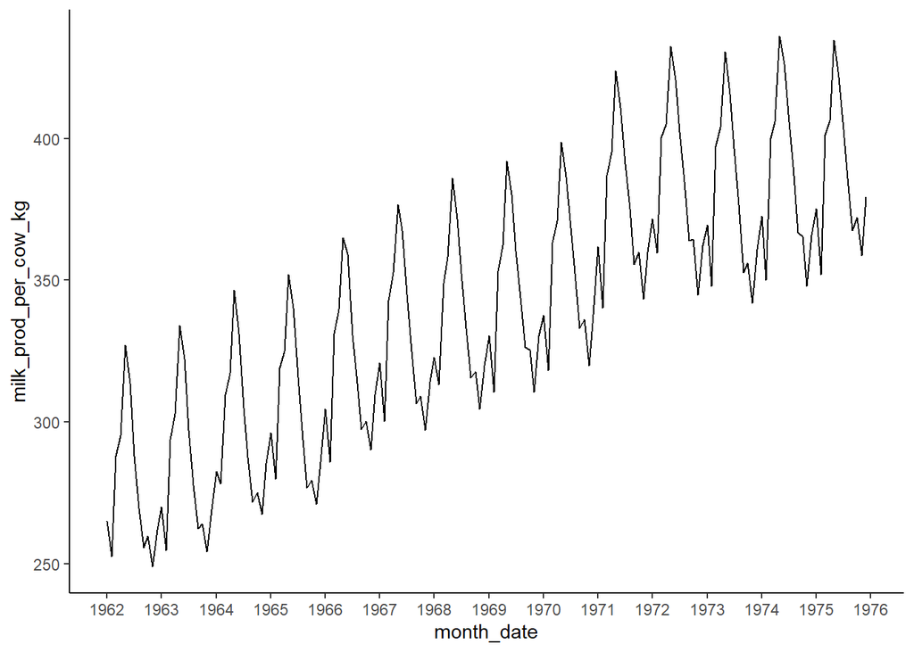

```r
(time_plot <- ggplot(monthly_milk, aes(x = month_date, y = milk_prod_per_cow_kg)) +
    geom_line() +
    scale_x_date(date_labels = "%Y", date_breaks = "1 year") +
    theme_classic())
```

Plotting date and time data is done similarly using scale_x_datetime():

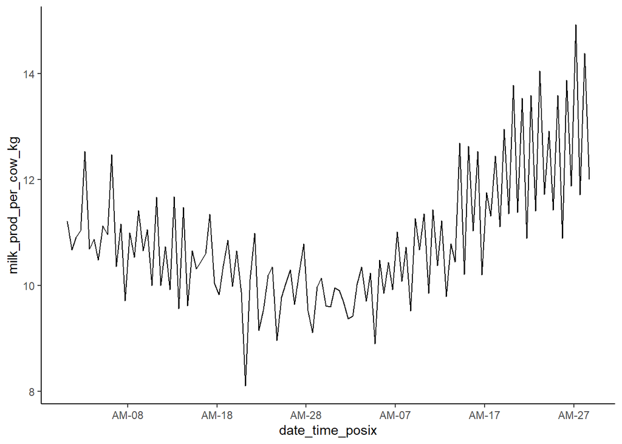

```r
(time_plot_2 <- ggplot(daily_milk, aes(x = date_time_posix, y = milk_prod_per_cow_kg)) +
    geom_line() +
    scale_x_datetime(date_labels = "%p-%d", date_breaks = "10 day") +
    theme_classic())
```

## 3. Statistical analysis of time series data